# Analyzing Individual BGG Users

Phil Henrickson

2022-01-02

# **Ham_pants’s** BoardGameGeek Collection

This notebook contains a set of analyses for the selected user’s boardgamegeek collection. The bulk of the analysis is focused on building a user-specific predictive model to predict the games that Ham_pants is likely to own. This enables to ask questions like, based on the games the user currently owns, what games are a good fit for their collection? What upcoming games are they likely to purchase?

This analysis is based on data from BoardGameGeek that was last updated on **2021-12-20.**

# 1 Collection Overview

We can look at a basic description of the number of games that the user owns, has rated, has previously owned, etc.

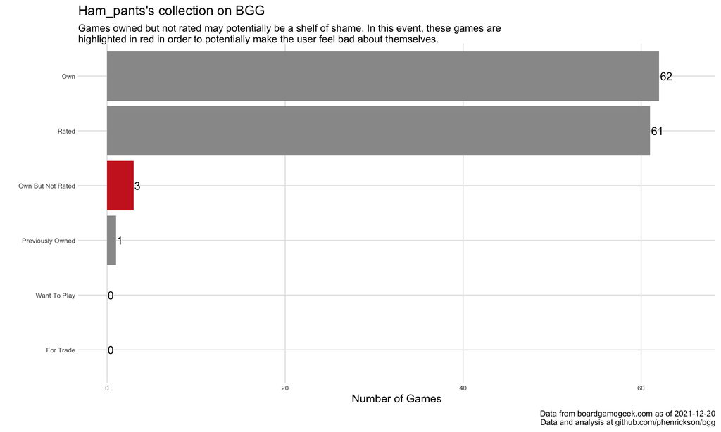

What years has the user owned/rated games from? While we can’t see when a user added or removed a game from their collection, we can look at their collection by the years in which their games were published.

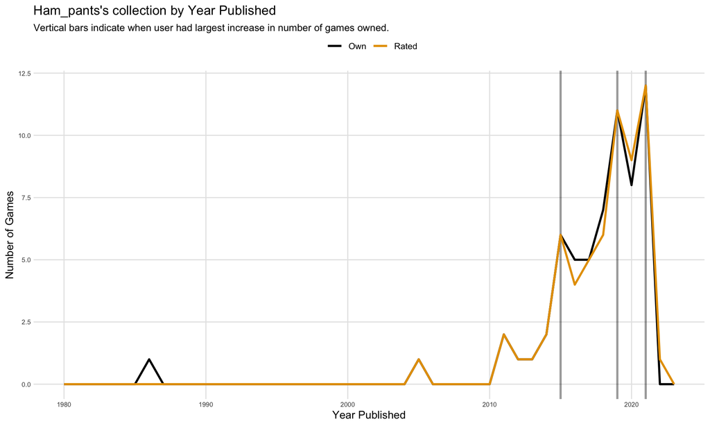

## 1.1 What types of games does Ham_pants own?

We can look at the most frequent types of categories, mechanics, designers, and artists that appear in a user’s collection.

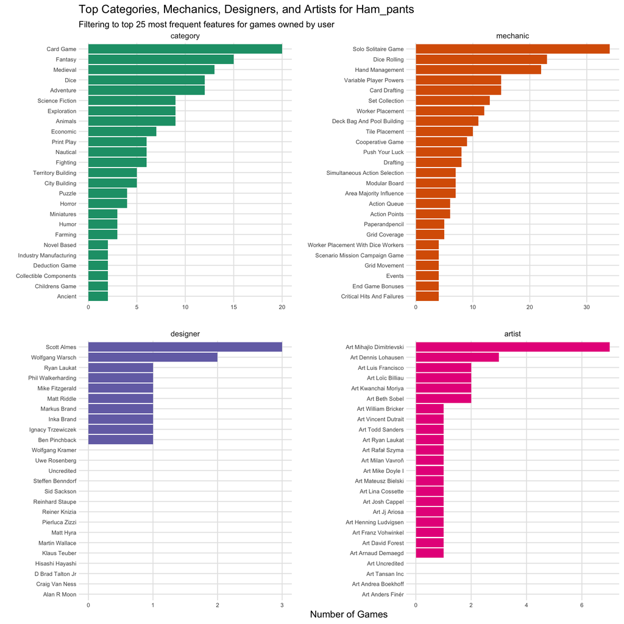

# 2 Modeling **Ham_pants’s** Collection

| username | dataset | period | games_owned | games_rated | games_played |
| --- | --- | --- | --- | --- | --- |
| Ham_pants | training | published before 2020 | 40 | 38 | 40 |
| Ham_pants | test | published 2020 or later | 20 | 22 | 22 |

There are two main (binary) outcomes we will be modeling for the user.

The first, **own** refers to whether the user currently lists a game as owned in their collection. The second, **played** refers to whether the user currently owns, has rated, or previously owned a game. This means the latter will generally have a larger list of games, but may still be a useful category to examine for people who play lots of games without necessarily owning them.

We will train predictive models to learn the probability that the user will own or play individual games based on their features.

## 2.1 Coefficients for Ham_pants

We can examine coefficients from the trained modes, which are penalized logistic regressions fit to our two main outcomes. Positive values indicate that a feature increases a user’s probabilility of owning/rating a game, while negative values indicate a feature decreases the probability.

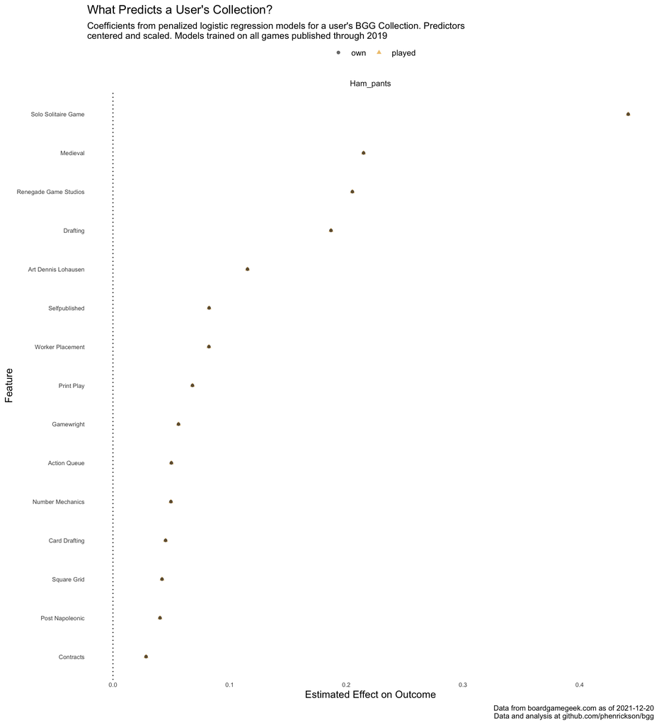

## 2.2 Visualizing Predictors for Ham_pants’s Collection

Why did the model identify these features? We can make density plots of the important features for predicting whether the user owned a game. Blue indicates the density for games owned by the user, while grey indicates the density for games not owned by the user.

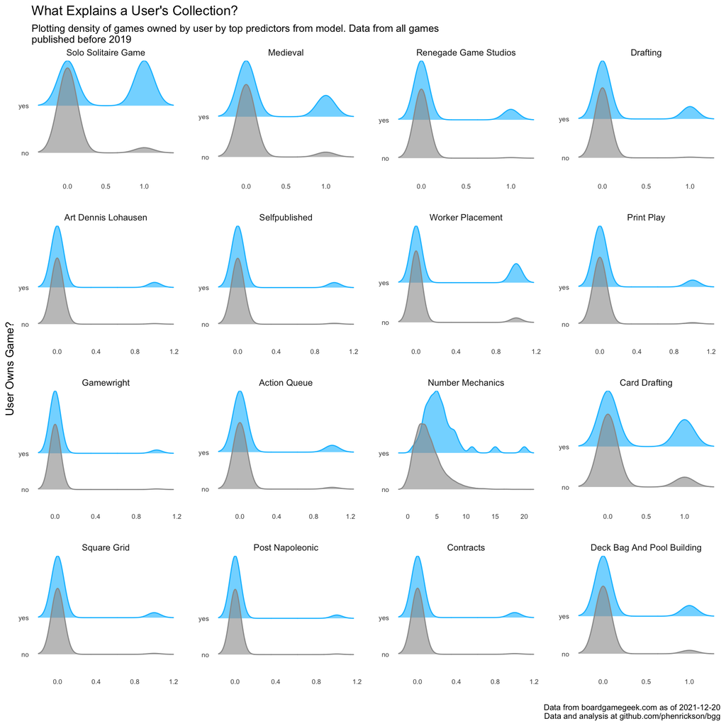

Binary predictors can be difficult to see with this visualization, so we can also directly examine the percentage of games in a user’s collection with a predictor vs the percentage of all games with that predictor.

| username | Feature | % of Games with Feature In_Collection | % of Games with Feature All_Games | Ratio |
| --- | --- | --- | --- | --- |
| Ham_pants | Renegade Game Studios | 15.0% | 0.8% | 18.2 |
| Ham_pants | Drafting | 17.5% | 1.0% | 18.0 |
| Ham_pants | Solo Solitaire Game | 50.0% | 5.7% | 8.7 |
| Ham_pants | Contracts | 7.5% | 1.0% | 7.4 |
| Ham_pants | Post Napoleonic | 5.0% | 0.9% | 5.6 |
| Ham_pants | Selfpublished | 7.5% | 1.4% | 5.3 |
| Ham_pants | Gamewright | 5.0% | 0.9% | 5.3 |
| Ham_pants | Square Grid | 7.5% | 1.4% | 5.3 |
| Ham_pants | Print Play | 10.0% | 1.9% | 5.2 |
| Ham_pants | Medieval | 27.5% | 6.2% | 4.4 |
| Ham_pants | Farming | 7.5% | 1.7% | 4.4 |
| Ham_pants | Worker Placement | 25.0% | 5.9% | 4.3 |
| Ham_pants | Action Queue | 10.0% | 2.5% | 4.0 |
| Ham_pants | Deck Bag And Pool Building | 15.0% | 4.8% | 3.1 |
| Ham_pants | Nautical | 10.0% | 3.5% | 2.9 |
| Ham_pants | Card Drafting | 32.5% | 11.8% | 2.7 |
| Ham_pants | Puzzle | 7.5% | 3.4% | 2.2 |
| Ham_pants | City Building | 7.5% | 4.3% | 1.8 |
| Ham_pants | Horror | 5.0% | 4.0% | 1.3 |
| Ham_pants | Party Game | 2.5% | 8.5% | 0.3 |
| Ham_pants | Wargame | 0.0% | 12.5% | 0.0 |
| Ham_pants | Word Game | 0.0% | 1.8% | 0.0 |
| Ham_pants | Negotiation | 0.0% | 3.7% | 0.0 |
| Ham_pants | Trivia | 0.0% | 1.8% | 0.0 |
| Ham_pants | Racing | 0.0% | 2.8% | 0.0 |

# 3 Assess Model’s Performance on Training Set

Before predicting games in upcoming years, we can examine how well the model did and what games it liked in the training set. In this case, we used resampling techniques (cross validation) to ensure that the model had not seen a game before making its predictions.

## 3.1 Separation Plot

An easy way to examine the performance of classification model is to view a separation plot. We plot the predicted probabilities from the model for every game (from resampling) from lowest to highest. We then overlay a blue line for any game that the user does own. A good classifier is one that is able to *separate* the blue (games owned by the user) from the white (games not owned by the user), with most of the blue occurring at the highest probabilities (right side of the chart).

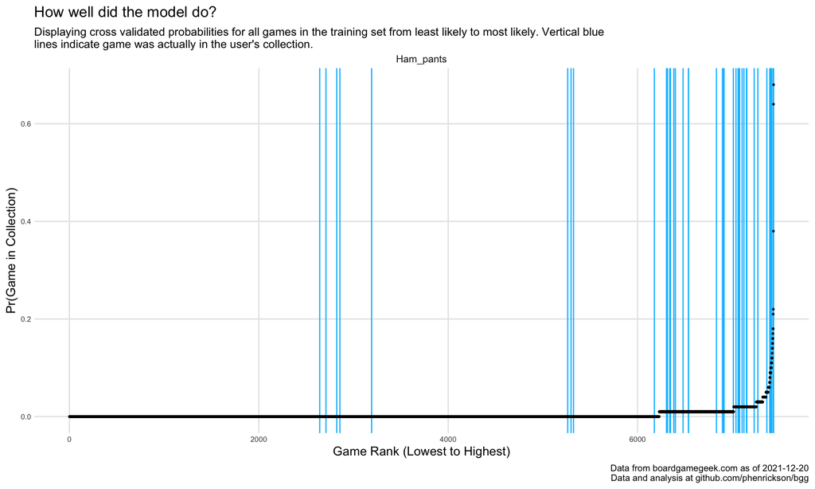

## 3.2 Top Games for **Ham_pants** from Training Set

We can display this information in table form, displaying the 100 games with the highest probability of ownership, adding a blue line when the user does own the game.

| username | yearpublished | game_id | name | pred_played | pred_own | actual_played | actual_own |
| --- | --- | --- | --- | --- | --- | --- | --- |
| Ham_pants | 2018 | 236457 | Architects of the West Kingdom | 0.68 | 0.68 | 1 | 1 |
| Ham_pants | 2015 | 171273 | FUSE | 0.64 | 0.64 | 0 | 0 |
| Ham_pants | 2018 | 241831 | Reykholt | 0.38 | 0.38 | 0 | 0 |
| Ham_pants | 2016 | 200680 | Agricola (Revised Edition) | 0.22 | 0.22 | 0 | 0 |
| Ham_pants | 2007 | 31260 | Agricola | 0.21 | 0.21 | 0 | 0 |
| Ham_pants | 2014 | 159675 | Fields of Arle | 0.18 | 0.18 | 0 | 0 |
| Ham_pants | 2019 | 266810 | Paladins of the West Kingdom | 0.18 | 0.18 | 1 | 1 |
| Ham_pants | 2019 | 283863 | The Magnificent | 0.17 | 0.17 | 0 | 0 |
| Ham_pants | 2016 | 198190 | Kepler-3042 | 0.16 | 0.16 | 0 | 0 |
| Ham_pants | 2016 | 167791 | Terraforming Mars | 0.16 | 0.16 | 0 | 0 |
| Ham_pants | 2019 | 268890 | Proving Grounds | 0.15 | 0.15 | 0 | 0 |
| Ham_pants | 2018 | 256313 | Spell Smashers | 0.15 | 0.15 | 0 | 0 |
| Ham_pants | 2017 | 201825 | Ex Libris | 0.14 | 0.14 | 0 | 0 |
| Ham_pants | 2012 | 119506 | Freedom: The Underground Railroad | 0.14 | 0.14 | 0 | 0 |
| Ham_pants | 2019 | 271324 | It's a Wonderful World | 0.14 | 0.14 | 0 | 0 |
| Ham_pants | 2017 | 216597 | Flatline | 0.13 | 0.13 | 0 | 0 |
| Ham_pants | 2015 | 182260 | Agent Decker | 0.12 | 0.12 | 0 | 0 |
| Ham_pants | 2018 | 218121 | Dice Hospital | 0.12 | 0.12 | 0 | 0 |
| Ham_pants | 2018 | 244711 | Newton | 0.12 | 0.12 | 0 | 0 |
| Ham_pants | 2019 | 283393 | Aquatica | 0.12 | 0.12 | 0 | 0 |
| Ham_pants | 2019 | 281259 | The Isle of Cats | 0.11 | 0.11 | 1 | 1 |
| Ham_pants | 2019 | 244099 | Herbaceous Sprouts | 0.11 | 0.11 | 0 | 0 |
| Ham_pants | 2015 | 168435 | Between Two Cities | 0.11 | 0.11 | 0 | 0 |
| Ham_pants | 2019 | 266192 | Wingspan | 0.11 | 0.11 | 1 | 1 |
| Ham_pants | 2018 | 256570 | Crown of Emara | 0.10 | 0.10 | 0 | 0 |
| Ham_pants | 2013 | 142992 | Gravwell: Escape from the 9th Dimension | 0.10 | 0.10 | 0 | 0 |
| Ham_pants | 2019 | 285984 | Last Bastion | 0.10 | 0.10 | 0 | 0 |
| Ham_pants | 2016 | 177736 | A Feast for Odin | 0.10 | 0.10 | 0 | 0 |
| Ham_pants | 2017 | 197376 | Charterstone | 0.10 | 0.10 | 0 | 0 |
| Ham_pants | 2016 | 72321 | The Networks | 0.10 | 0.10 | 0 | 0 |

[output cut: 70 more lines]

We can also more formally assess how well the model did in resampling by looking at the area under the receiver operating characteristic. A perfect model would receive a score of 1, while a model that cannot predict the outcome will default to a score of 0.5. The extent to which something is a *good* score depends on the setting, but generally anything in the .8 to .9 range is very good while the .7 to .8 range is perfectly acceptable.

| username | outcome_type | .metric | .estimator | .estimate |
| --- | --- | --- | --- | --- |
| Ham_pants | own | roc_auc | binary | 0.84 |
| Ham_pants | played | roc_auc | binary | 0.84 |

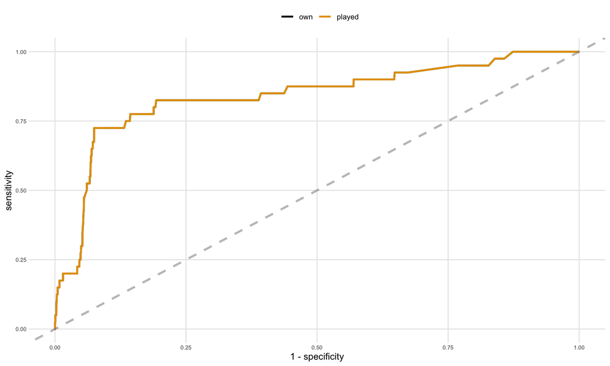

Another way to think about the model performance is to view its lift, or its ability to detect the positive outcomes over that of a null model. High lift indicates the model can much more quickly find all of the positive outcomes (in this case, games owned or played by the user), while a model with no lift is no better than random guessing.

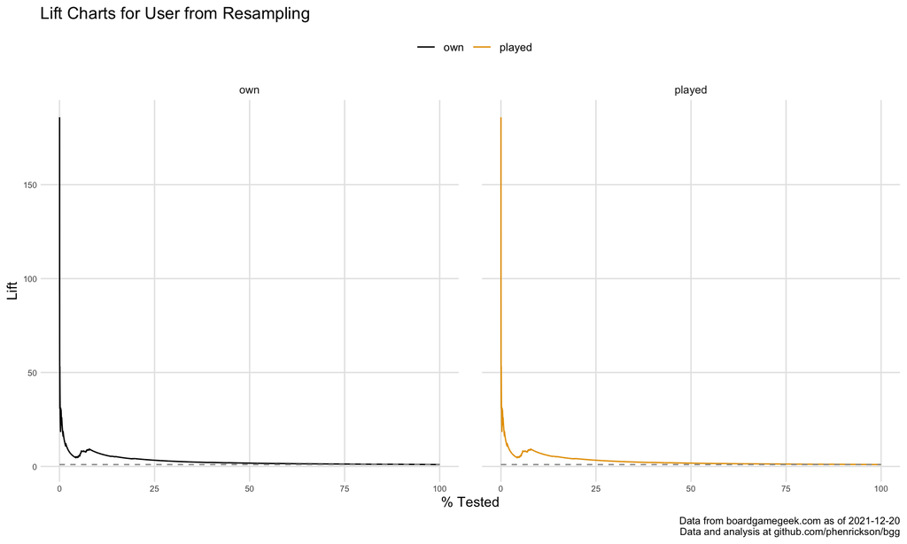

## 3.3 Most and Least Likely Games

What games does the model think Ham_pants is **most likely to own** that are **not** in their collection?

| username | yearpublished | game_id | name | pred_own | actual_own |
| --- | --- | --- | --- | --- | --- |
| Ham_pants | 2015 | 171273 | FUSE | 0.64 | 0 |
| Ham_pants | 2018 | 241831 | Reykholt | 0.38 | 0 |
| Ham_pants | 2016 | 200680 | Agricola (Revised Edition) | 0.22 | 0 |
| Ham_pants | 2007 | 31260 | Agricola | 0.21 | 0 |
| Ham_pants | 2014 | 159675 | Fields of Arle | 0.18 | 0 |

What games does the model think Ham_pants is **least likely to own** that **are** in their collection?

| username | yearpublished | game_id | name | pred_own | actual_own |
| --- | --- | --- | --- | --- | --- |
| Ham_pants | 2017 | 222407 | Lignum (Second Edition) | 0 | 1 |
| Ham_pants | 1986 | 1219 | Labyrinth | 0 | 1 |
| Ham_pants | 2014 | 172931 | Outfoxed! | 0 | 1 |
| Ham_pants | 2018 | 242324 | Stew | 0 | 1 |
| Ham_pants | 2017 | 234190 | Unstable Unicorns | 0 | 1 |

## 3.4 Top Games by Year

Top 25 games most likely to be owned by the user in each year, highlighting in blue the games that the user has owned/played.

| rank | 2011 | 2012 | 2013 | 2014 | 2015 | 2016 | 2017 | 2018 | 2019 |
| --- | --- | --- | --- | --- | --- | --- | --- | --- | --- |
| 1 | Friday | Freedom: The Underground Railroad | Gravwell: Escape from the 9th Dimension | Fields of Arle | FUSE | Agricola (Revised Edition) | Ex Libris | Architects of the West Kingdom | Paladins of the West Kingdom |
| 2 | Trajan | The Manhattan Project | Maquis | La Granja | Agent Decker | Kepler-3042 | Flatline | Reykholt | The Magnificent |
| 3 | Field Commander: Napoleon | In Magnificent Style: Pickett's Charge at Gettysburg | Castle Dice | Imperial Settlers | Between Two Cities | Terraforming Mars | Charterstone | Spell Smashers | Proving Grounds |
| 4 | Village | Nuklear Winter '68 | Lewis & Clark: The Expedition | Elevenses for One | The Pursuit of Happiness | A Feast for Odin | D100 Dungeon | Dice Hospital | It's a Wonderful World |
| 5 | Gears of War: The Board Game | Thunderbolt Apache Leader | Navajo Wars | Machina Arcana | Raiders of the North Sea | The Networks | Raging Bulls | Newton | Aquatica |
| 6 | Dungeons & Dragons: Wrath of Ashardalon Board Game | Level 7 [Escape] | Pathfinder Adventure Card Game: Rise of the Runelords – Base Set | Legendary Encounters: An Alien Deck Building Game | Rolling America | Star Trek: The Dice Game | Bargain Quest | Crown of Emara | The Isle of Cats |
| 7 | Sentinels of the Multiverse | Robinson Crusoe: Adventures on the Cursed Island | Legacy: The Testament of Duke de Crecy | Patchwork | Cat Tower | One Deck Dungeon | Castles of Caladale | Gunkimono | Herbaceous Sprouts |
| 8 | Space Infantry | Hoplomachus: The Lost Cities | The Doom That Came to Atlantic City | Roll Through the Ages: The Iron Age | The Maiden in the Forest | Four Against Darkness | Bunny Kingdom | That's Pretty Clever! | Wingspan |
| 9 | Steam Torpedo: First Contact | Escape: The Curse of the Temple | Hoplomachus: Rise of Rome | DungeonQuest Revised Edition | Dice City | Kingdomino | Sagrada | Sprawlopolis | Last Bastion |
| 10 | Infidel | Kingdom of Heaven: The Crusader States 1097-1291 | The Hunters: German U-Boats at War, 1939-43 | Greenland | Sylvion | Sherlock Holmes Consulting Detective: Jack the Ripper & West End Adventures | Pocket Mars | 1066, Tears to Many Mothers | Yukon Airways |
| 11 | Battle of LITS | Targi | Dawn of the Zeds (Second edition) | Praetor | My Village | Expedition: The Roleplaying Card Game | Twin Stars: Adventure Series I | Palm Island | Era of Kingdoms |
| 12 | The Castles of Burgundy | Game of Thrones: The Card Game | Cruel Necessity: The English Civil Wars 1640-1653 | Fleet Commander: Nimitz – The WWII Pacific Ocean Solitaire Strategy Game | Trickerion: Legends of Illusion | Honshū | Merlin | Lords of Hellas | Crusader Kings |
| 13 | Drum Roll | For the Crown (Second Edition) | Glass Road | The Lord of the Ice Garden | Bullfrogs | Agricola, Master of Britain | Wendake | Age of Towers | Chai |
| 14 | Principato | Agricola: All Creatures Big and Small | Firefly: The Game | Fire in the Lake | Tiny Epic Defenders | Inis | A4 Quest | Pax Emancipation | Carnival of Monsters |
| 15 | Feudalia | Vampire Empire | The Hobbit: An Unexpected Journey | Dragon's Hoard | Kitty Paw | Aeon's End | Pendragon: The Fall of Roman Britain | Key Flow | Pax Pamir: Second Edition |
| 16 | Ora et Labora | Urbion | Archon: Glory & Machination | Roll Through the Ages: The Iron Age with Mediterranean Expansion | SteamRollers | Clank!: A Deck-Building Adventure | Gaia Project | Metro X | Legends Untold: The Great Sewers Novice Set |
| 17 | Santiago de Cuba | Dark Horse | A Distant Plain | Doodle Quest | Hoplomachus: Origins | Planet Defenders | Herbaceous | Village Attacks | The Taverns of Tiefenthal |
| 18 | Ninjato | Tzolk'in: The Mayan Calendar | Caverna: The Cave Farmers | 1944: Race to the Rhine | Airborne Commander | World's Fair 1893 | Fireworks | Maiden's Quest | Clank!: Legacy – Acquisitions Incorporated |
| 19 | The Red Dragon Inn 3 | Divided Republic | Yunnan | Enemy Coast Ahead: The Dambuster Raid | Deep Space D-6 | La Granja: No Siesta | This War of Mine: The Board Game | Goblivion | Amul |
| 20 | Trollhalla | Andean Abyss | SOS Titanic | Tiny Epic Kingdoms | Coffee Roaster | Dokmus | One Deck Dungeon: Forest of Shadows | Unbroken | Ragusa |
| 21 | Artus | Seasons | Castellan | Pandemic: The Cure | Brick Party | Apotheca | Hostage Negotiator: Crime Wave | Crystallo | Squire for Hire |
| 22 | Walnut Grove | Edo | The Duke | Heroes of Normandie | Blood Rage | Silent Victory: U.S. Submarines in the Pacific, 1941-45 | First Martians: Adventures on the Red Planet | Bargain Basement Bathysphere | Florenza Dice Game |
| 23 | Tournay | OddVille | King & Assassins | Consentacle | Burgle Bros. | Nautilion | Clank! In! Space!: A Deck-Building Adventure | The City of Kings | Era: Medieval Age |
| 24 | Coney Island | City of Gears | Cube Quest | Blood & Roses | Kingdom Death: Monster | The Blood of an Englishman | Pie Town | Dark Souls: The Card Game | Villagers |
| 25 | Mage Knight Board Game | Kairo | Hanamikoji | Onirim (Second Edition) | Thunderbirds | Mr. Cabbagehead's Garden | Sentient | Realm of Sand | Lux Aeterna |

## 3.5 Interactive Predictions from Resampling

Interactive table for predictions from resampling.

|  | username | yearpublished | rank | game_id | name | pred_played | pred_own | actual_played | actual_own |
| --- | --- | --- | --- | --- | --- | --- | --- | --- | --- |
| 1 | Ham_pants | 1900 | 238 | 10400 | Patience | 0.02 | 0.02 | 0 | 0 |
| 2 | Ham_pants | 1900 | 425 | 188 | Go | 0.01 | 0.01 | 0 | 0 |
| 3 | Ham_pants | 1900 | 435 | 171 | Chess | 0.01 | 0.01 | 0 | 0 |
| 4 | Ham_pants | 1900 | 437 | 2065 | Shogi | 0.01 | 0.01 | 0 | 0 |
| 5 | Ham_pants | 1900 | 505 | 10213 | Fox and Geese | 0.01 | 0.01 | 0 | 0 |
| 6 | Ham_pants | 1900 | 545 | 7316 | Bingo | 0.01 | 0.01 | 0 | 0 |
| 7 | Ham_pants | 1900 | 753 | 21389 | Happy Families | 0.01 | 0.01 | 0 | 0 |
| 8 | Ham_pants | 1900 | 864 | 4505 | Tarot | 0.01 | 0.01 | 0 | 0 |
| 9 | Ham_pants | 1900 | 893 | 6901 | Euchre | 0.01 | 0.01 | 0 | 0 |
| 10 | Ham_pants | 1900 | 981 | 5432 | Chutes and Ladders | 0.01 | 0.01 | 0 | 0 |

[output cut: 7426 more lines]

# 4 Validating the Model on 2020

How well did a model trained on a user’s collection through 2019 perform in predicting games for the user from 2020?

| username | outcome_type | yearpublished | .metric | .estimator | .estimate |
| --- | --- | --- | --- | --- | --- |
| Ham_pants | own | 2020 | roc_auc | binary | 0.915 |
| Ham_pants | played | 2020 | roc_auc | binary | 0.915 |

Table of top 25 games from 2020, highlighting games that the user owns.

| username | yearpublished | game_id | name | pred_own | pred_played | actual_own | actual_played |
| --- | --- | --- | --- | --- | --- | --- | --- |
| Ham_pants | 2020 | 296151 | Viscounts of the West Kingdom | 0.29 | 0.29 | 1 | 1 |
| Ham_pants | 2020 | 301880 | Raiders of Scythia | 0.23 | 0.23 | 0 | 0 |
| Ham_pants | 2020 | 184267 | On Mars | 0.20 | 0.20 | 0 | 0 |
| Ham_pants | 2020 | 307844 | Atheneum: Mystic Library | 0.18 | 0.18 | 0 | 0 |
| Ham_pants | 2020 | 317231 | Monasterium | 0.16 | 0.16 | 0 | 0 |
| Ham_pants | 2020 | 279537 | The Search for Planet X | 0.13 | 0.13 | 0 | 0 |
| Ham_pants | 2020 | 296237 | Warp's Edge | 0.13 | 0.13 | 1 | 1 |
| Ham_pants | 2020 | 298130 | Amalfi | 0.13 | 0.13 | 0 | 0 |
| Ham_pants | 2020 | 270143 | Kōhaku | 0.09 | 0.09 | 0 | 0 |
| Ham_pants | 2020 | 281466 | Yedo: Deluxe Master Set | 0.08 | 0.08 | 0 | 0 |
| Ham_pants | 2020 | 306040 | Merv: The Heart of the Silk Road | 0.08 | 0.08 | 0 | 0 |
| Ham_pants | 2020 | 309600 | Archers of Nand | 0.08 | 0.08 | 0 | 0 |
| Ham_pants | 2020 | 313698 | Monster Expedition | 0.07 | 0.07 | 0 | 0 |
| Ham_pants | 2020 | 269420 | Ragemore | 0.06 | 0.06 | 0 | 0 |
| Ham_pants | 2020 | 278042 | Crusader Kingdoms: The War for the Holy Land | 0.06 | 0.06 | 0 | 0 |
| Ham_pants | 2020 | 304420 | Bonfire | 0.06 | 0.06 | 0 | 0 |
| Ham_pants | 2020 | 284742 | Honey Buzz | 0.05 | 0.05 | 0 | 0 |
| Ham_pants | 2020 | 300322 | Hallertau | 0.05 | 0.05 | 0 | 0 |
| Ham_pants | 2020 | 306029 | Dark Force Incursion | 0.05 | 0.05 | 0 | 0 |
| Ham_pants | 2020 | 147635 | Dungeon Crusade: Book I – Genesis of Evil | 0.04 | 0.04 | 0 | 0 |
| Ham_pants | 2020 | 174959 | The First Jihad: The Rise of Islam 632-750 | 0.04 | 0.04 | 0 | 0 |
| Ham_pants | 2020 | 262208 | Dungeon Drop | 0.04 | 0.04 | 0 | 0 |
| Ham_pants | 2020 | 266188 | Seven Bridges | 0.04 | 0.04 | 0 | 0 |
| Ham_pants | 2020 | 269489 | The Mission: Early Christianity from the Crucifixion to the Crusades | 0.04 | 0.04 | 0 | 0 |
| Ham_pants | 2020 | 292333 | Cowboys II: Cowboys & Indians Edition | 0.04 | 0.04 | 0 | 0 |

# 5 Predicting Upcoming Games (2020 and On) for **Ham_pants**

Examine the top games for the test set.

| username | yearpublished | game_id | name | rank | own | played |
| --- | --- | --- | --- | --- | --- | --- |
| Ham_pants | 2020 | 296151 | Viscounts of the West Kingdom | 1 | 0.29 | 0.29 |
| Ham_pants | 2020 | 301880 | Raiders of Scythia | 2 | 0.23 | 0.23 |
| Ham_pants | 2020 | 184267 | On Mars | 3 | 0.20 | 0.20 |
| Ham_pants | 2020 | 307844 | Atheneum: Mystic Library | 4 | 0.18 | 0.18 |
| Ham_pants | 2020 | 317231 | Monasterium | 5 | 0.16 | 0.16 |
| Ham_pants | 2020 | 298130 | Amalfi | 6 | 0.13 | 0.13 |
| Ham_pants | 2020 | 296237 | Warp's Edge | 7 | 0.13 | 0.13 |
| Ham_pants | 2020 | 279537 | The Search for Planet X | 8 | 0.13 | 0.13 |
| Ham_pants | 2020 | 270143 | Kōhaku | 9 | 0.09 | 0.09 |
| Ham_pants | 2020 | 281466 | Yedo: Deluxe Master Set | 10 | 0.08 | 0.08 |
| Ham_pants | 2020 | 306040 | Merv: The Heart of the Silk Road | 11 | 0.08 | 0.08 |
| Ham_pants | 2020 | 309600 | Archers of Nand | 12 | 0.08 | 0.08 |
| Ham_pants | 2020 | 313698 | Monster Expedition | 13 | 0.07 | 0.07 |
| Ham_pants | 2020 | 304420 | Bonfire | 14 | 0.06 | 0.06 |
| Ham_pants | 2020 | 269420 | Ragemore | 15 | 0.06 | 0.06 |
| Ham_pants | 2020 | 278042 | Crusader Kingdoms: The War for the Holy Land | 16 | 0.06 | 0.06 |
| Ham_pants | 2020 | 300322 | Hallertau | 17 | 0.05 | 0.05 |
| Ham_pants | 2020 | 306029 | Dark Force Incursion | 18 | 0.05 | 0.05 |
| Ham_pants | 2020 | 284742 | Honey Buzz | 19 | 0.05 | 0.05 |
| Ham_pants | 2020 | 292333 | Cowboys II: Cowboys & Indians Edition | 20 | 0.04 | 0.04 |
| Ham_pants | 2020 | 262208 | Dungeon Drop | 21 | 0.04 | 0.04 |
| Ham_pants | 2020 | 293556 | Gloomy Graves | 22 | 0.04 | 0.04 |
| Ham_pants | 2020 | 294275 | Way of the Samurai | 23 | 0.04 | 0.04 |
| Ham_pants | 2020 | 302465 | Obsidia | 24 | 0.04 | 0.04 |
| Ham_pants | 2020 | 309110 | Food Chain Island | 25 | 0.04 | 0.04 |
| Ham_pants | 2021 | 340834 | Gravwell: 2nd Edition | 1 | 0.19 | 0.19 |
| Ham_pants | 2021 | 252752 | Genotype: A Mendelian Genetics Game | 2 | 0.18 | 0.18 |
| Ham_pants | 2021 | 314088 | Agropolis | 3 | 0.17 | 0.17 |
| Ham_pants | 2021 | 314589 | Night Parade of a Hundred Yokai | 4 | 0.17 | 0.17 |
| Ham_pants | 2021 | 304783 | Hadrian's Wall | 5 | 0.13 | 0.13 |
| Ham_pants | 2021 | 336195 | League of Dungeoneers | 6 | 0.10 | 0.10 |
| Ham_pants | 2021 | 295947 | Cascadia | 7 | 0.10 | 0.10 |
| Ham_pants | 2021 | 301441 | Drawn to Adventure | 8 | 0.10 | 0.10 |
| Ham_pants | 2021 | 315624 | World Changers | 9 | 0.09 | 0.09 |
| Ham_pants | 2021 | 344277 | Corrosion | 10 | 0.08 | 0.08 |
| Ham_pants | 2021 | 342942 | Ark Nova | 11 | 0.07 | 0.07 |
| Ham_pants | 2021 | 329593 | Settlement | 12 | 0.06 | 0.06 |
| Ham_pants | 2021 | 206757 | Glory: A Game of Knights | 13 | 0.06 | 0.06 |
| Ham_pants | 2021 | 306202 | Philosophia: Floating World | 14 | 0.06 | 0.06 |
| Ham_pants | 2021 | 303954 | Pax Viking | 15 | 0.05 | 0.05 |
| Ham_pants | 2021 | 348955 | Rock Paper Scissors: Deluxe Edition | 16 | 0.05 | 0.05 |
| Ham_pants | 2021 | 320960 | Roll In One | 17 | 0.04 | 0.04 |
| Ham_pants | 2021 | 313695 | Lost In Straya | 18 | 0.04 | 0.04 |
| Ham_pants | 2021 | 287711 | The Path of the Adventurers | 19 | 0.04 | 0.04 |
| Ham_pants | 2021 | 285192 | Destinies | 20 | 0.04 | 0.04 |
| Ham_pants | 2021 | 322560 | Maeshowe: an Orkney Saga | 21 | 0.04 | 0.04 |
| Ham_pants | 2021 | 313269 | Rescuing Robin Hood | 22 | 0.04 | 0.04 |
| Ham_pants | 2021 | 331787 | Tiny Epic Dungeons | 23 | 0.04 | 0.04 |
| Ham_pants | 2021 | 337765 | Brian Boru: High King of Ireland | 24 | 0.04 | 0.04 |
| Ham_pants | 2021 | 295535 | Dark Ages: Heritage of Charlemagne | 25 | 0.04 | 0.04 |
| Ham_pants | 2022 | 334065 | Verdant | 1 | 0.11 | 0.11 |
| Ham_pants | 2022 | 319807 | Shogun no Katana | 2 | 0.06 | 0.06 |
| Ham_pants | 2022 | 284118 | Mechanical Beast | 3 | 0.05 | 0.05 |
| Ham_pants | 2022 | 305096 | Endless Winter: Paleoamericans | 4 | 0.03 | 0.03 |
| Ham_pants | 2022 | 280726 | Legacies | 5 | 0.03 | 0.03 |
| Ham_pants | 2022 | 304051 | Creature Comforts | 6 | 0.03 | 0.03 |
| Ham_pants | 2022 | 322524 | Bardsung | 7 | 0.03 | 0.03 |
| Ham_pants | 2022 | 328866 | My Father's Work | 8 | 0.03 | 0.03 |
| Ham_pants | 2022 | 305462 | The Age of Atlantis | 9 | 0.03 | 0.03 |
| Ham_pants | 2022 | 219650 | Arydia: The Paths We Dare Tread | 10 | 0.02 | 0.02 |
| Ham_pants | 2022 | 286063 | The 7th Citadel | 11 | 0.02 | 0.02 |
| Ham_pants | 2022 | 294529 | Entropia: The Game | 12 | 0.02 | 0.02 |
| Ham_pants | 2022 | 303731 | Primal: The Awakening | 13 | 0.02 | 0.02 |
| Ham_pants | 2022 | 284842 | So, You've Been Eaten | 14 | 0.02 | 0.02 |
| Ham_pants | 2022 | 295374 | Long Shot: The Dice Game | 15 | 0.02 | 0.02 |
| Ham_pants | 2022 | 282775 | The Warp | 16 | 0.02 | 0.02 |
| Ham_pants | 2022 | 311988 | Frostpunk: The Board Game | 17 | 0.02 | 0.02 |
| Ham_pants | 2022 | 331401 | Dog Park | 18 | 0.02 | 0.02 |
| Ham_pants | 2022 | 342444 | Black Rose Wars: Rebirth | 19 | 0.02 | 0.02 |
| Ham_pants | 2022 | 299106 | Fractal: Beyond the Void | 20 | 0.02 | 0.02 |
| Ham_pants | 2022 | 312959 | Rallyman: DIRT | 21 | 0.02 | 0.02 |
| Ham_pants | 2022 | 256680 | Return to Dark Tower | 22 | 0.02 | 0.02 |
| Ham_pants | 2022 | 322589 | Zapotec | 23 | 0.02 | 0.02 |
| Ham_pants | 2022 | 317321 | Darkest Dungeon: The Board Game | 24 | 0.02 | 0.02 |
| Ham_pants | 2022 | 324090 | Scarface 1920 | 25 | 0.02 | 0.02 |

## 5.1 Interactive Table for Upcoming Games 2020 and On

|  | username | yearpublished | game_id | name | rank | own | played |
| --- | --- | --- | --- | --- | --- | --- | --- |
| 1 | Ham_pants | 2020 | 296151 | Viscounts of the West Kingdom | 1 | 0.29 | 0.29 |
| 2 | Ham_pants | 2020 | 301880 | Raiders of Scythia | 2 | 0.23 | 0.23 |
| 3 | Ham_pants | 2020 | 184267 | On Mars | 3 | 0.2 | 0.2 |
| 4 | Ham_pants | 2021 | 340834 | Gravwell: 2nd Edition | 4 | 0.19 | 0.19 |
| 5 | Ham_pants | 2021 | 252752 | Genotype: A Mendelian Genetics Game | 5 | 0.18 | 0.18 |
| 6 | Ham_pants | 2020 | 307844 | Atheneum: Mystic Library | 6 | 0.18 | 0.18 |
| 7 | Ham_pants | 2021 | 314088 | Agropolis | 7 | 0.17 | 0.17 |
| 8 | Ham_pants | 2021 | 314589 | Night Parade of a Hundred Yokai | 8 | 0.17 | 0.17 |
| 9 | Ham_pants | 2020 | 317231 | Monasterium | 9 | 0.16 | 0.16 |
| 10 | Ham_pants | 2020 | 298130 | Amalfi | 10 | 0.13 | 0.13 |

[output cut: 1627 more lines]